# Communicate-Data-Findings(Ford GoBike System Data Flights)

## by (Dhuha Baqarish)

### The Data

###### Each trip is anonymized and includes:

- Trip Duration (seconds)
- Start Time and Date
- End Time and Date
- Start Station ID
- Start Station Name
- Start Station Latitude
- Start Station Longitude
- End Station ID
- End Station Name
- End Station Latitude
- End Station Longitude
- Bike ID
- User Type (Subscriber or Customer – “Subscriber” = Member or “Customer” = Casual)
- Member Year of Birth
- Member Gende

```python
# Import all packages and set plots to be embedded inline
import numpy as np
import pandas as pd
import matplotlib.pyplot as plt
import seaborn as sb

%matplotlib inline
```

```python
#### Reading data
df = pd.read_csv('2017-fordgobike-tripdata.csv')
```

```python
df.head()
```

|  | duration_sec | start_time | end_time | start_station_id | start_station_name | start_station_latitude | start_station_longitude | end_station_id | end_station_name | end_station_latitude | end_station_longitude | bike_id | user_type | member_birth_year | member_gender |
| --- | --- | --- | --- | --- | --- | --- | --- | --- | --- | --- | --- | --- | --- | --- | --- |
| 0 | 80110 | 2017-12-31 16:57:39.6540 | 2018-01-01 15:12:50.2450 | 74 | Laguna St at Hayes St | 37.776435 | -122.426244 | 43 | San Francisco Public Library (Grove St at Hyde... | 37.778768 | -122.415929 | 96 | Customer | 1987.0 | Male |
| 1 | 78800 | 2017-12-31 15:56:34.8420 | 2018-01-01 13:49:55.6170 | 284 | Yerba Buena Center for the Arts (Howard St at ... | 37.784872 | -122.400876 | 96 | Dolores St at 15th St | 37.766210 | -122.426614 | 88 | Customer | 1965.0 | Female |
| 2 | 45768 | 2017-12-31 22:45:48.4110 | 2018-01-01 11:28:36.8830 | 245 | Downtown Berkeley BART | 37.870348 | -122.267764 | 245 | Downtown Berkeley BART | 37.870348 | -122.267764 | 1094 | Customer | NaN | NaN |
| 3 | 62172 | 2017-12-31 17:31:10.6360 | 2018-01-01 10:47:23.5310 | 60 | 8th St at Ringold St | 37.774520 | -122.409449 | 5 | Powell St BART Station (Market St at 5th St) | 37.783899 | -122.408445 | 2831 | Customer | NaN | NaN |
| 4 | 43603 | 2017-12-31 14:23:14.0010 | 2018-01-01 02:29:57.5710 | 239 | Bancroft Way at Telegraph Ave | 37.868813 | -122.258764 | 247 | Fulton St at Bancroft Way | 37.867789 | -122.265896 | 3167 | Subscriber | 1997.0 | Female |

```python
# Describe the data
df.info()
```

```
<class 'pandas.core.frame.DataFrame'>
RangeIndex: 519700 entries, 0 to 519699
Data columns (total 15 columns):
duration_sec               519700 non-null int64
start_time                 519700 non-null object
end_time                   519700 non-null object
start_station_id           519700 non-null int64
start_station_name         519700 non-null object
start_station_latitude     519700 non-null float64
start_station_longitude    519700 non-null float64
end_station_id             519700 non-null int64
end_station_name           519700 non-null object
end_station_latitude       519700 non-null float64
end_station_longitude      519700 non-null float64
bike_id                    519700 non-null int64
user_type                  519700 non-null object
member_birth_year          453159 non-null float64
member_gender              453238 non-null object
dtypes: float64(5), int64(4), object(6)
memory usage: 59.5+ MB
```

```python
# Number of rows and columns in dataset
df.shape
```

```
(519700, 15)
```

```python
# No null value in the datast
df.isnull().sum()
```

```
duration_sec                   0
start_time                     0
end_time                       0
start_station_id               0
start_station_name             0
start_station_latitude         0
start_station_longitude        0
end_station_id                 0
end_station_name               0
end_station_latitude           0
end_station_longitude          0
bike_id                        0
user_type                      0
member_birth_year          66541
member_gender              66462
dtype: int64
```

#### Define

we have a null values

#### Code

```python
df.dropna(inplace=True)
```

#### Test

```python
df.isnull().sum()
```

```
duration_sec               0
start_time                 0
end_time                   0
start_station_id           0
start_station_name         0
start_station_latitude     0
start_station_longitude    0
end_station_id             0
end_station_name           0
end_station_latitude       0
end_station_longitude      0
bike_id                    0
user_type                  0
member_birth_year          0
member_gender              0
dtype: int64
```

```python
df.member_birth_year=df.member_birth_year.astype(int)
```

```python
#fixing data type
df['start_time']=pd.to_datetime(df['start_time'])
df['end_time']=pd.to_datetime(df['end_time'])
```

```python
#new columns to use
df['hour'] = df.start_time.dt.hour
```

#### test

```python
df.info()
```

[output not shown]

### What is the structure of your dataset?

> There are 519700 rides in the dataset with 15 features like
> - bike_id,
> - duration_sec,
> - start_time,
> - end_time,
> - user_type,
> - member_age,
> - start_station_name ... etc

and Most variables are numeric in the dataset

### What is/are the main feature(s) of interest in your dataset?

> I'm most interested in ;
> - Riding duration
> - Age groups of users
> - Genders

### What features in the dataset do you think will help support your investigation into your feature(s) of interest?

> I expect that age group and purpose of usage will make a strong effect in the dataset

find age of member

```python
len(df.member_birth_year )
```

```
453159
```

```python
df['member_age'] = 2019-df['member_birth_year']
```

```python
df.member_age.count()
```

```
453159
```

```python
df['duration_min']=df['duration_sec']/60
```

```python
df.info()
```

[output not shown]

## Univariate Exploration

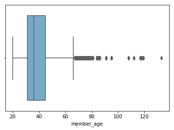

```python
sb.boxplot(x='member_age', data=df, palette='Blues', orient='h')
```

##### Define

There are outliers in the ages. We will discard these abnormal ages since we are more interested in bikers age from 20 to 60.

##### Code

```python
df=df[df['member_age'] <=60]
np.mean(df.member_age)
```

```
37.5353645191863
```

#### Test

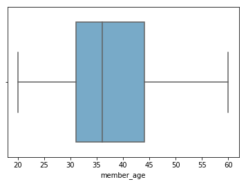

```python
sb.boxplot(x='member_age', data=df, palette='Blues', orient='h')
```

- The mean age is 37 years old

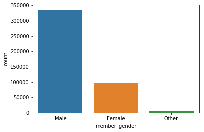

```python
sb.countplot(data = df, x = 'member_gender')
plt.savefig('pic2.png')
```

- There are significantly more males cyclists than females and other genders.

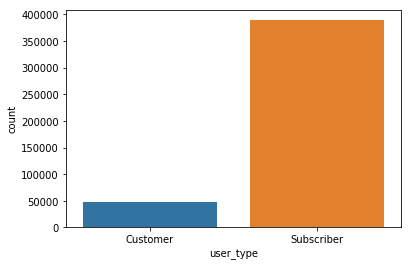

```python
sb.countplot(data = df, x = 'user_type')
```

- The number Subscribers is more than the Customers

### Of the features you investigated, were there any unusual distributions? Did you perform any operations on the data to tidy, adjust, or change the form of the data? If so, why did you do this?

> There are outliers in the ages. We will discard these abnormal ages since we are more interested in bikers age from 20 to 60.

## Bivariate Exploration

```
Text(0.5,0,'minutes [trip duration]')
```

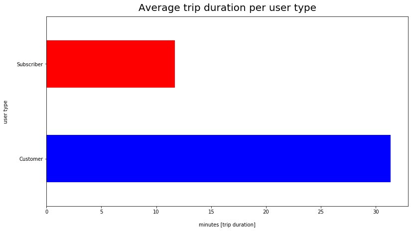

```python
new_color=['blue', 'red']
ax = df.groupby('user_type')['duration_min'].mean().plot(kind='barh', color=new_color, figsize=(13,7))
ax.set_title('Average trip duration per user type', fontsize=20, y=1.015)
ax.set_ylabel('user type', labelpad=16)
ax.set_xlabel('minutes [trip duration]', labelpad=16)
```

The durations time of Customer is more than the durations time of Subscriber

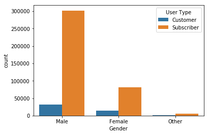

```python
sb.countplot(data=df, x='member_gender', hue='user_type')
plt.xlabel('Gender')
plt.legend(title='User Type');
```

The number of Subscriber in both gender (Male,Female) is more than the number of Customer

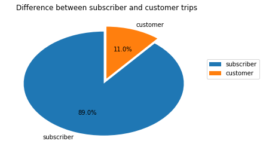

```python
# plot user_type relative numbers
subscriber = len(df[df['user_type'] == 'Subscriber'])
customer = len(df[df['user_type'] != 'Subscriber'])

x_labels = ['subscriber', 'customer']
y = [subscriber, customer]
explode = (0.1, 0)
plt.pie(y, labels = x_labels, explode = explode, startangle=90, autopct='%1.1f%%')
plt.legend (labels = x_labels, loc = (1, 0.5))
plt.title('Difference between subscriber and customer trips');
```

Difference between subscriber and customer trips

### Talk about some of the relationships you observed in this part of the investigation. How did the feature(s) of interest vary with other features in the dataset?

> The average trip durations for the Customers type is longer than average trip durations for the subscribers type

## Multivariate Exploration

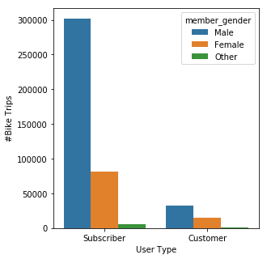

```python
plt.figure(figsize = [10, 5])

plt.subplot(1, 2, 1)

g = sb.countplot(data=df, x="user_type", hue="member_gender", order=df.user_type.value_counts().index)
g.set_xlabel('User Type')
g.set_ylabel('#Bike Trips');
```

Always the males have higher rate for both Subscriber and Customer

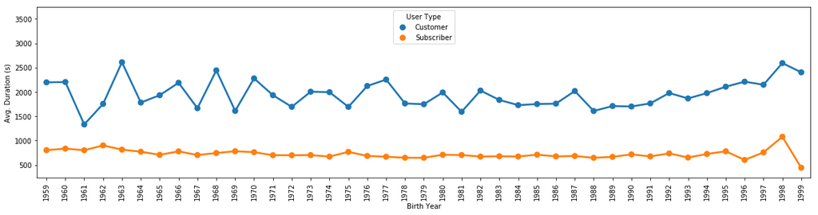

```python
plt.figure(figsize=[20, 10])

# plot the point plot of the birth year vs. user type
plt.subplot(2, 1, 1)
sb.pointplot(data=df, x='member_birth_year', y='duration_sec', errwidth=0, hue='user_type')
plt.xticks(rotation=90)
plt.xlabel('Birth Year')
plt.ylabel('Avg. Duration (s)')
plt.legend(title='User Type')
```

The graph shows that the customer has a higher average duration than subscriber

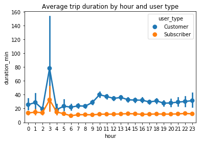

```python
sb.pointplot(data=df, x='hour', y='duration_min', hue='user_type');
plt.title('Average trip duration by hour and user type');
```

Relationship between hour of the trip, trip duration and user type

### Talk about some of the relationships you observed in this part of the investigation. Were there features that strengthened each other in terms of looking at your feature(s) of interest?

> Numbers of members of different gender (both male, female, and other) in subscribers field more than in customers

### Were there any interesting or surprising interactions between features?

> The numbers of members male subscribers is so large the average trip duration that was high from 1am to 4am and highest at 3 am